# OVERVIEW

The general objective for this study is to establish the effect of credit management on the profitability of deposit money banks in Nigeria. The specific objective of the study includes to:

- Examine the effect of loans and advances, nonperforming loans, loan loss provisions on the return on assets (ROA), of deposit money banks in Nigeria.
- Determine the effect of loans and advances, nonperforming loans, loan loss provisions on the return of equity (ROE) of deposit money banks in Nigeria
- Ascertain the effect of loans and advance, non-performing loans, loan loss provisions on the return on capital employed (ROCE) of deposit money banks in Nigeria.

## DATA OVERVIEW

The Dataset is comprises of 60 rows and 9 columns; the columns in the dataset are:

- ID: Unique count for the dataset, serves as primary key.
- Bank: The name of the bank in short
- Year: The relevant accounting year for which the value was calculated/derived
- ROA: The Return on Asset calculated as Net Income/Total Asset
- ROE: The Return on Equit calculated as Net Income/Total Equity
- ROCE: The Return on Capital Employed, calculated as EBIT/(TE + NTL)
- NPL: Non Performing Loans
- LA: Loan and Amortization
- LLP: Loan Loss Provision

## RESEARCH QUESTIONS

In order to achieve the above study objectives, the research aims at addressing the following questions in relation to the selected banks.

- To what extent does loans and advances, nonperforming loans, loan loss provisions on the return on assets (ROA) of deposit money banks in Nigeria.
- What is the effect of loans and advances, nonperforming loans, loan loss provisions on the return of equity (ROE) of deposit money banks in Nigeria.
- To what extent does loans and advance, non-performing loans, loan loss provisions on the return on capital employed (ROCE) of deposit money banks in Nigeria.

## Test of Hypothesis

Hypotheses to be tested in this study are stated below in their null forms:

$H_1$: There is no effect of loans and advances, nonperforming loans, loan loss provisions on the return on assets (ROA) of deposit money banks in Nigeria.

$H_2$: There is no effect of loans and advances, nonperforming loans, loan loss provisions on the return on equity (ROE) of deposit money banks in Nigeria.

$H_3$: There is no effect of loans and advances, nonperforming loans, loan loss provisions on the return on capital employed (ROCE) of deposit money banks in Nigeria.

```python
# Load libraries
# Data manipulation libraries
import numpy as np
import pandas as pd

# Data visualization libraries
from matplotlib import pyplot as plt
import seaborn as sns

# Statistical Libraries
import statsmodels.api as sm
from scipy.stats import ttest_ind, chi2_contingency, f_oneway
from statsmodels.stats.proportion import proportions_ztest
from sklearn.preprocessing import MinMaxScaler
```

### Read and Inspect Data

```python
# load the data
data = pd.read_excel('data_new.xlsx', 'Sheet1')

# Load first 5 rows
data.head()
```

|  | ID | Bank | Year | ROA | ROE | ROCE | NPL | L&A | LLP |
| --- | --- | --- | --- | --- | --- | --- | --- | --- | --- |
| 0 | 1 | access | 2022 | 0.011713 | 0.148632 | 0.013456 | 192098.0 | 5556517.0 | 96738.000 |
| 1 | 2 | access | 2021 | 0.013656 | 0.152582 | 0.015062 | 181659.0 | 4445912.0 | 88084.968 |
| 2 | 3 | access | 2020 | 0.012213 | 0.141151 | 0.014508 | 161242.0 | 3610928.0 | 119341.162 |
| 3 | 4 | access | 2019 | 0.013167 | 0.155020 | 0.015669 | 188462.0 | 3064405.0 | 144784.315 |
| 4 | 5 | access | 2018 | 0.019172 | 0.193636 | 0.020829 | 55449.0 | 2136096.0 | 80634.272 |

#### Checks

```python
# Number of rows and columns
rows, columns = data.shape

print(f"There are {rows} rows and {columns} columns in the data")

# Missing Values
miss_vals = data.isnull().sum().sum()

print(f"There are {miss_vals} missing values in the data")

# Check for duplicate values
dup_vals = data.duplicated().sum().sum()

print(f"There are {dup_vals} duplicated values in the data.\n")

# Description of the data
data_des = data.describe()
data_des
```

```
There are 60 rows and 9 columns in the data
There are 0 missing values in the data
There are 0 duplicated values in the data.
```

|  | ID | Year | ROA | ROE | ROCE | NPL | L&A | LLP |
| --- | --- | --- | --- | --- | --- | --- | --- | --- |
| count | 60.000000 | 60.000000 | 60.000000 | 60.000000 | 60.000000 | 60.000000 | 6.000000e+01 | 60.000000 |
| mean | 30.500000 | 2020.000000 | 0.022097 | 0.147576 | 0.024091 | 50830.649135 | 1.931330e+07 | 50522.286138 |
| std | 17.464249 | 1.426148 | 0.020573 | 0.085281 | 0.022287 | 49684.185013 | 6.489922e+07 | 41679.271062 |
| min | 1.000000 | 2018.000000 | -0.036500 | -0.012100 | -0.035800 | 0.000000 | 1.367036e+05 | 984.000000 |
| 25% | 15.750000 | 2019.000000 | 0.009451 | 0.091989 | 0.009399 | 12940.250000 | 6.566780e+05 | 17489.259000 |
| 50% | 30.500000 | 2020.000000 | 0.014050 | 0.144325 | 0.017200 | 42584.274500 | 1.580249e+06 | 40248.000000 |
| 75% | 45.250000 | 2021.000000 | 0.033233 | 0.218640 | 0.038407 | 67023.250000 | 2.892024e+06 | 81725.177500 |
| max | 60.000000 | 2022.000000 | 0.112600 | 0.337011 | 0.113300 | 192098.000000 | 3.110882e+08 | 152178.697140 |

# EXPLORATORY DATA ANALYSIS

## UNIVARIATE ANALYSIS

#### Functions

```python
# Function to create a box plot and histogram for the variables
def histogram_boxplot(data, feature, figsize=(15, 10), kde=False, bins=None):
    """
    Boxplot and histogram combined

    data: dataframe
    feature: dataframe column
    figsize: size of figure (default (15,10))
    kde: whether to show the density curve (default False)
    bins: number of bins for histogram (default None)
    """
    f2, (ax_box2, ax_hist2) = plt.subplots(
        nrows=2,  # Number of rows of the subplot grid= 2
        sharex=True,  # x-axis will be shared among all subplots
        gridspec_kw={"height_ratios": (0.25, 0.75)},
        figsize=figsize,
    )  # creating the 2 subplots
    sns.boxplot(
        data=data, x=feature, ax=ax_box2, showmeans=True, color="violet"
    )  # boxplot will be created and a triangle will indicate the mean value of the column
    sns.histplot(
        data=data, x=feature, kde=kde, ax=ax_hist2, bins=bins
    ) if bins else sns.histplot(
        data=data, x=feature, kde=kde, ax=ax_hist2
    )  # For histogram
    ax_hist2.axvline(
        data[feature].mean(), color="green", linestyle="--"
    )  # Add mean to the histogram
    ax_hist2.axvline(
        data[feature].median(), color="black", linestyle="-"
    )  # Add median to the histogram
```

```python
# function to create labeled barplots
def labeled_barplot(data, feature, perc=False, n=None):
    """
    Barplot with percentage at the top

    data: dataframe
    feature: dataframe column
    perc: whether to display percentages instead of count (default is False)
    n: displays the top n category levels (default is None, i.e., display all levels)
    """

    total = len(data[feature])  # length of the column
    count = data[feature].nunique()
    if n is None:
        plt.figure(figsize=(count + 2, 6))
    else:
        plt.figure(figsize=(n + 2, 6))

    plt.xticks(rotation=90, fontsize=15)
    ax = sns.countplot(
        data=data,
        x=feature,
        palette="Paired",
        order=data[feature].value_counts().index[:n],
    )

    for p in ax.patches:
        if perc == True:
            label = "{:.1f}%".format(
                100 * p.get_height() / total
            )  # percentage of each class of the category
        else:
            label = p.get_height()  # count of each level of the category

        x = p.get_x() + p.get_width() / 2  # width of the plot
        y = p.get_height()  # height of the plot

        ax.annotate(
            label,
            (x, y),
            ha="center",
            va="center",
            size=12,
            xytext=(0, 5),
            textcoords="offset points",
        )  # annotate the percentage

    plt.show()  # show the plot
```

#### ROA

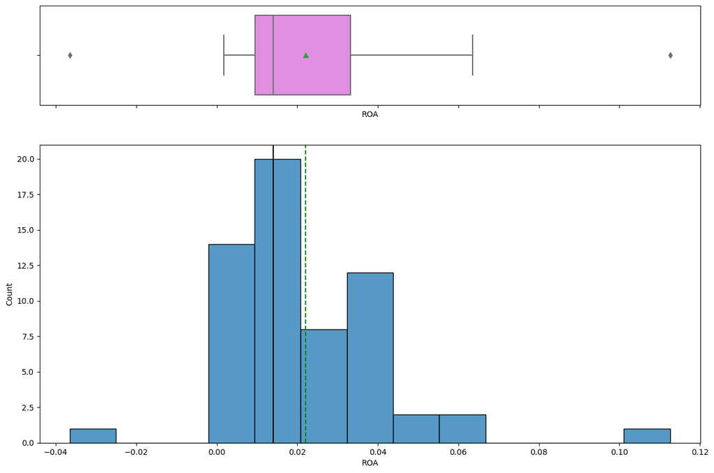

```python
histogram_boxplot(data, "ROA")
```

#### ROE

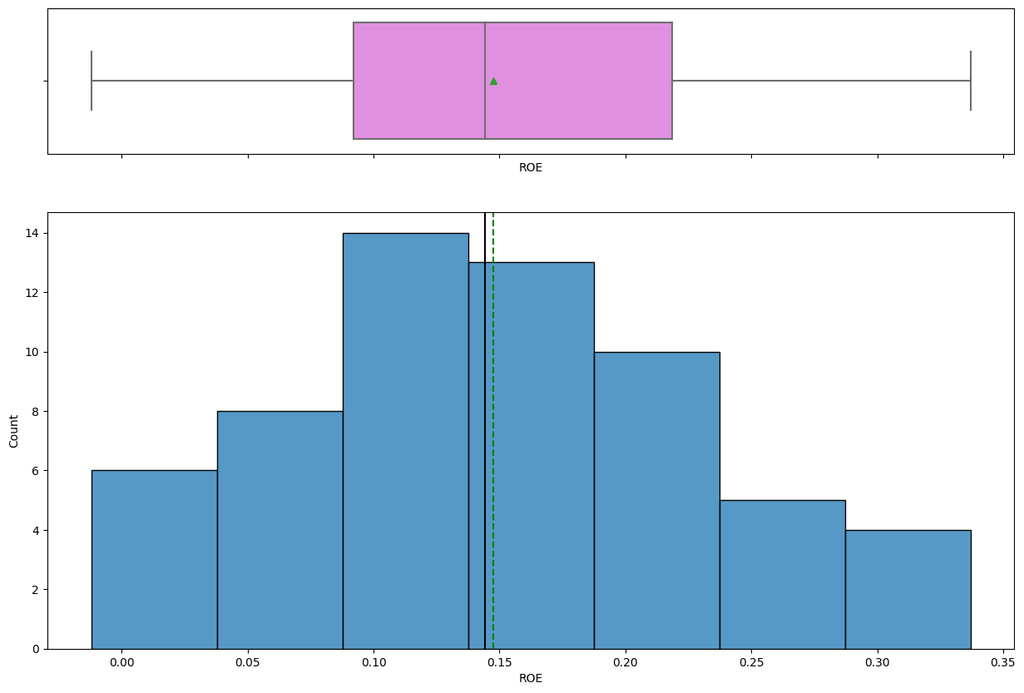

```python
histogram_boxplot(data, "ROE")
```

#### ROCE

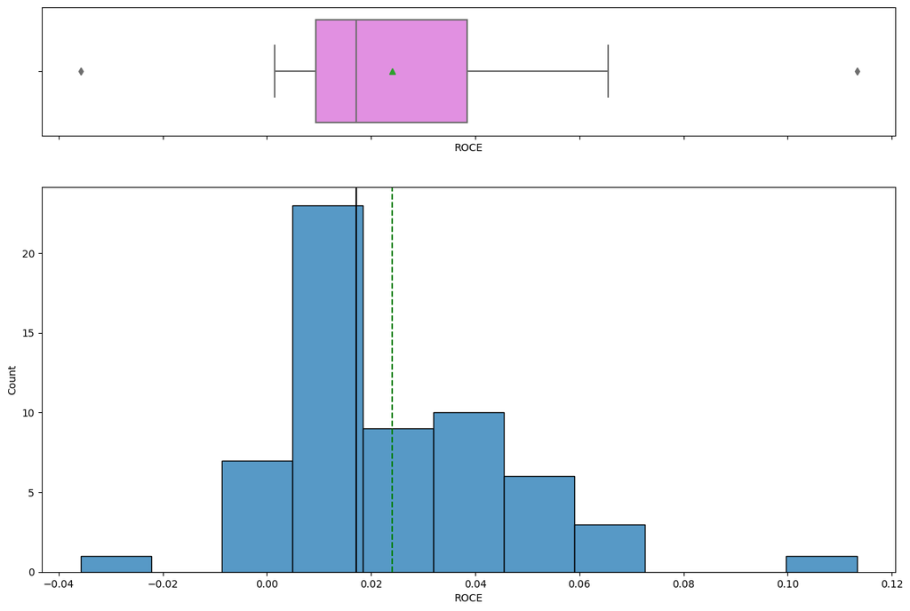

```python
histogram_boxplot(data, "ROCE")
```

#### LLP

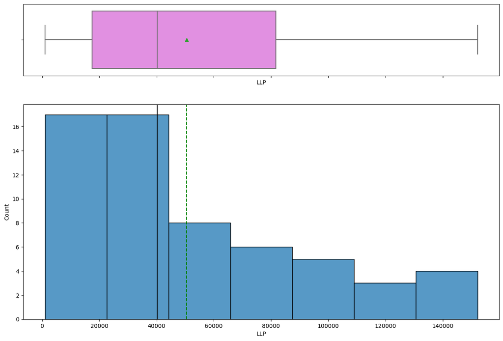

```python
histogram_boxplot(data, "LLP")
```

#### NPL

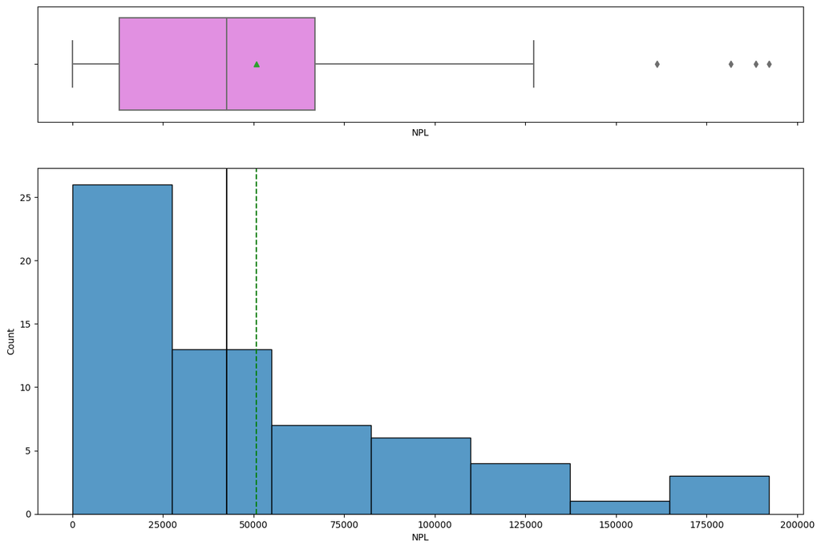

```python
histogram_boxplot(data, "NPL")
```

#### L&A

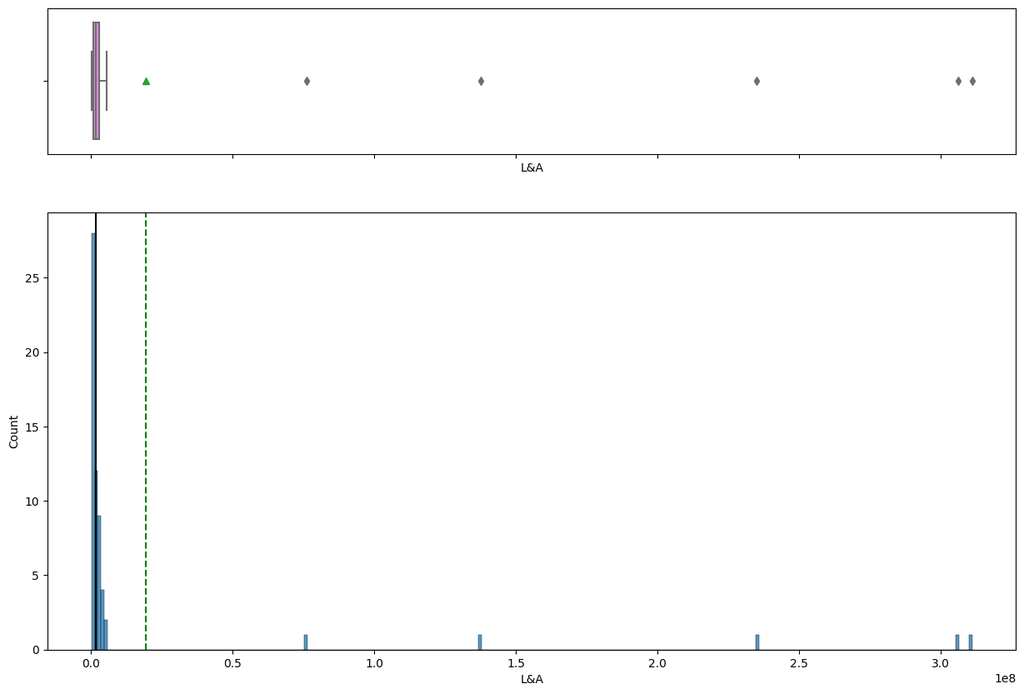

```python
histogram_boxplot(data, "L&A")
```

#### Bank

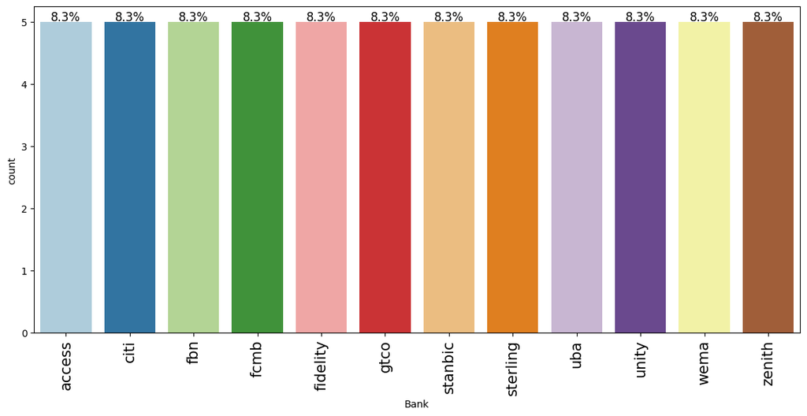

```python
labeled_barplot(data, "Bank", perc=True)
```